# Sequential Uncertainty Reduction and Value of Information in Gaussian Process Models

Consider the situation where a farmer must decide wether to harvest a forest with uncertain profits, or just to leave it for conservation and receive 0 profits.

The Forest: $25 \times 25$ grid, consisting of 625 units of cells $(1,1),(1,2),\dots,(25,25)$.

[figure not shown]

- $a=0$: leave all cells for conservation
- $a=1$: harvest all cells

Cells: $\mathbf{s} = (s_1,s_2)$

The profit in each cell: $ \mathbf{x} = (x_1,\dots,x_{625})$

Expected profit: $\mathbf{E}[x(\mathbf{s})] = \mathbf{0}$

Variance of profit: $\mathrm{Var}[x(\mathbf{s})] = 1^2 $

Covariance of profit between cells: $\mathrm{Cov}[x(\mathbf{s}),x(\mathbf{s'})] = \exp(-0.15h), \enspace \textrm{where } h = \sqrt{||\mathbf{s}-\mathbf{s}'||^2}$

Gives the prior of profit: $\mathbf{x} \sim \mathcal{N}[\mathbf{0},\mathbf{\Sigma}]$

[figure not shown]

Each cell sampled with: $y(\mathbf{s}) = x(\mathbf{s}) + \mathcal{N}[0,5^2]$

The $j$th line sampled with(the likelihood): $\mathbf{y}_j|\mathbf{x} \sim \mathbf{F}_j\mathbf{x} + \mathcal{N}[\mathbf{0},\mathbf{T}] = \mathcal{N}[\mathbf{F}_j\mathbf{x},\mathbf{T}]$

$\mathbf{F}_j$ is of size $25 \times 625$ picks entries from $\mathbf{x}$

new mean : $\boldsymbol{\mu}_j = \boldsymbol{\mu} + \mathbf{\Sigma}\mathbf{F}_j^T(\mathbf{F}_j\mathbf{\Sigma}\mathbf{F}_j^T + \mathbf{T})^{-1}(\mathbf{y}_j - \mathbf{F}_j\boldsymbol{\mu})$

new covariance: $\mathbf{\Sigma}_j = \mathbf{\Sigma} - \mathbf{\Sigma}\mathbf{F}_j^T(\mathbf{F}_j\mathbf{\Sigma}\mathbf{F}_j^T + \mathbf{T})^{-1}\mathbf{F}_j\mathbf{\Sigma}$

```python
N = 25
m = 625
def create_grid(m,N):
    Sigma = np.identity(m)
    s = np.zeros((2,m))
    T = np.identity(N)*5**2
    mu = np.zeros(m)
    for i in range(N):
        for j in range(N):
            s[:,j + i*N] = [i+1,j+1]
    for i in range(m-1):
        for j in range(i+1,m):
            Sigma[i,j] = Sigma[j,i] = np.exp(-0.15*np.sqrt((s[0,i] - s[0,j])**2 + (s[1,i] - s[1,j])**2))
    return s, mu, Sigma, T
```

```python
s, mu, Sigma, T = create_grid(m,N)
```

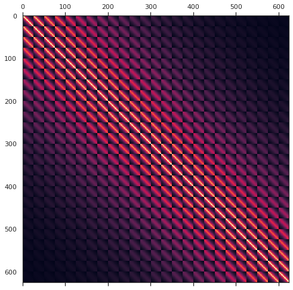

```python
plt.matshow(Sigma);
```

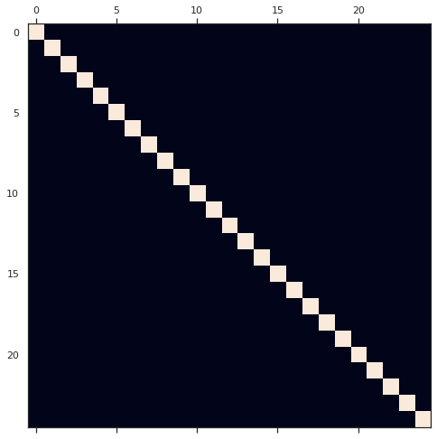

```python
plt.matshow(T);
```

```python
def get_F_j(m,N,j):
    F_j = np.zeros((N,m))
    for i in range(N):
        for k in range(N):
            F_j[i,k*N + j-1] = 1
    return F_j

def get_Sigma_j(m,N,j,Sigma,T):
    F_j = get_F_j(m,N,j)
    tmp = (F_j@Sigma@F_j.transpose() + T)
    tmp = np.linalg.inv(tmp)
    Sigma_j = Sigma - Sigma@F_j.transpose()@tmp@F_j@Sigma
    return Sigma_j, F_j
```

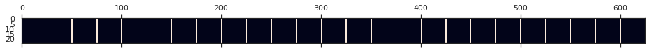

```python
F_j = get_F_j(m,N,1)
plt.matshow(F_j);
```

## Select the line $j$ that maximises the reduction in the mean variance of the grid

$$j^* = \underset{j}{\mathrm{argmin}}\frac{1}{625}\sum_{k=1}^{625} \Sigma_j(k,k)$$

```python
def max_reduc_mean_var(m,N,Sigma,T):
    tmp_min = np.inf
    tmp_min_j = np.nan
    for j in range(1,26):
        Sigma_j, F_j = get_Sigma_j(m,N,j,Sigma,T)
        tmp_mean_var = np.diag(Sigma_j).mean()
        if tmp_mean_var < tmp_min:
            tmp_min = tmp_mean_var
            tmp_min_j = j
    return tmp_min_j
```

```python
min_j= max_reduc_mean_var(m,N,Sigma,T)
print("Line {} maximizes the reduction in mean variance".format(min_j))
```

```
Line 13 maximizes the reduction in mean variance
```

## Conduct sequential selecton of lines

$$\mathbf{\Sigma}_j = \mathbf{\Sigma} - \mathbf{\Sigma}\mathbf{F}_j^T(\mathbf{F}_j\mathbf{\Sigma}\mathbf{F}_j^T + \mathbf{T})^{-1}\mathbf{F}_j\mathbf{\Sigma}$$

### Find the 10 first lines:

```python
def ten_lines(m,N):
    s, mu, Sigma, T = create_grid(m,N)
    for i in range(10):
        min_j = max_reduc_mean_var(m,N,Sigma,T)
        Sigma_j, F_j = get_Sigma_j(m,N,min_j,Sigma,T)
        Sigma = Sigma_j
        print("Line {} maximizes the reduction in mean variance".format(min_j))
    return mu, Sigma
```

```python
mu, Sigma = ten_lines(m,N)
```

```
Line 13 maximizes the reduction in mean variance
Line 22 maximizes the reduction in mean variance
Line 4 maximizes the reduction in mean variance
Line 9 maximizes the reduction in mean variance
Line 18 maximizes the reduction in mean variance
Line 1 maximizes the reduction in mean variance
Line 25 maximizes the reduction in mean variance
Line 15 maximizes the reduction in mean variance
Line 7 maximizes the reduction in mean variance
Line 20 maximizes the reduction in mean variance
```

[figure not shown]

## Decision making: harvest ($a=1$), or not to harvest ($a=0$)

Prior value: $$PV = \max_{a\in A} \{\mathbf{E}[v(\mathbf{x},a)]\}$$

$$ = \max\left\{0,\sum_{k=1}^{625} \mu_k\right\}$$

Posterior value: $$ PoV (\mathbf{y}) = \int \max_{a\in A} \left\{\mathbf{E}[v(\mathbf{x},a)|\mathbf{y}] \right\}p(\mathbf{y})\mathrm{d}\mathbf{y}$$

$$ = \sum_y \max_{a\in A} \left\{\mathbf{E}[v(\mathbf{x},a)|y)\right\}p(y)$$

$$ = \mu_w\Phi(\mu_w/r_{w,j}) + r_{w,j}\phi(\mu_w/r_{w,j})$$

Where: $$\mu_w = \sum_i \mu_i$$ $$\mathbf{R}_j =\mathbf{\Sigma}\mathbf{F}_j^T(\mathbf{F}_j\mathbf{\Sigma}\mathbf{F}_j^T + \mathbf{T})^{-1}\mathbf{F_j}\mathbf{\Sigma}$$ $$r_{w,j} = \sqrt{\sum_k\sum_l R_j(k,l)}$$ $$ \Phi(\cdot)\enspace - \textrm{ the standard normal CDF}$$ $$ \phi(\cdot)\enspace - \textrm{ the standard normal PDF}$$

Value of Information: $$VOI(\mathbf{y}) = PoV(\mathbf{y}) - PV $$

### Myopic Scheme

\begin{equation*} \boxed{\begin{array}{ll} \textrm{Initiate:} & \mathbf{x}, \boldsymbol{\mu}, \mathbf{\Sigma}\\ \textrm{Find:} & j^* = \underset{j}{\mathrm{argmin}} \frac{1}{m}\sum_{k=1}^m \Sigma_j(k,k)\\ \textrm{Calc:} & \mathbf{R}_{j^*}, \mu_w, r_{w,j^*}, \mathrm{VOI}_{j^*}\\ \textrm{While }\mathrm{VOI}_{j^*} > P: & \\ \hspace{25pt}\textrm{Collect data:} & \mathbf{y}_{j^*}\\ \hspace{25pt}\textrm{Update model:} & \boldsymbol{\mu} = \boldsymbol{\mu}+\mathbf{\Sigma}\mathbf{F}_{j^*}^T(\mathbf{F}_{j^*}\mathbf{\Sigma}\mathbf{F}_{j^*}^T + \mathbf{T})^{-1}(\mathbf{y}_{j^*} - \mathbf{F}_{j^*}\boldsymbol{\mu}) \\ & \mathbf{\Sigma} \mathrel{{-}{=}} \mathbf{R}_{j^*}\\ \hspace{25pt}\textrm{Find:} & j^* = \underset{j}{\mathrm{min}} \frac{1}{m}\sum_{k=1}^m \Sigma_j(k,k)\\ \hspace{25pt}\textrm{Calc:} & \mathbf{R}_{j^*}, \mu_w, r_{w,j^*}, \mathrm{VOI}_{j^*}\\ \end{array}} \end{equation*}

```python
def sample_y_j(mu,Sigma,F_j,T):
    return np.random.multivariate_normal(F_j @ mu,
                                         F_j @ Sigma @ F_j.transpose() + T)
```

```python
# function calculating the value of information
def value_of_information(mu_w,r_w,PV):
    return mu_w*norm.cdf(mu_w/r_w) + r_w*norm.pdf(mu_w/r_w) - PV
```

```python
# code of the myopic scheme
def sequential_voi(m,N):
    s, mu, Sigma, T = create_grid(m,N)
    min_j = max_reduc_mean_var(m,N,Sigma,T)
    Sigma_j, F_j = get_Sigma_j(m,N,min_j,Sigma,T)
    mu_w = mu.sum()
    r_w = np.sqrt((Sigma-Sigma_j).sum())
    PV = 0
    voi = value_of_information(mu_w,r_w,PV)
    # creating ouput lists
    lines = []
    voi_list = []
    n_lines = 0
    while voi > 0.5:
        lines.append(min_j)
        voi_list.append(voi)
        n_lines += 1
        y_j = sample_y_j(mu,Sigma,F_j,T)
        mu = mu + Sigma @ F_j.transpose()@np.linalg.inv(T + F_j@Sigma@F_j.transpose())@(y_j-F_j@mu)
        Sigma = Sigma_j
        PV = np.max([mu.sum(),0])
        min_j = max_reduc_mean_var(m,N,Sigma,T)
        Sigma_j, F_j = get_Sigma_j(m,N,min_j,Sigma,T)
        mu_w = mu.sum()
        r_w = np.sqrt((Sigma-Sigma_j).sum())
        voi = value_of_information(mu_w,r_w,PV)
    return lines, int(n_lines),voi_list
```

```python
lines, n_lines,voi = sequential_voi(m,N)
print("Example run selected {} lines, and the lines where {}".format(n_lines,lines))
```

```
Example run selected 3 lines, and the lines where [13, 22, 4]
```

## 100 replicated trials

```python
rep_trials = 100
lines_df = pd.DataFrame({"lines":[],
                        "trial":[],
                        "voi":[]})
for i in range(rep_trials):
    lines, n_lines, voi = sequential_voi(m,N)
    lines_df = lines_df.append(
        pd.DataFrame({"lines":lines,
                      "trial":[i+1]*int(n_lines),
                      "voi":voi}),
        ignore_index = True)
    print("Trial {}: {} lines".format(i+1,n_lines),end="\r")
```

```
Trial 100: 3 lines
```

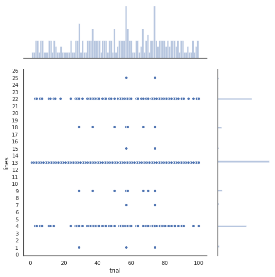

```python
g = sns.jointplot(x="trial", y="lines", data=lines_df,marginal_kws=dict(bins=100),height=8, ratio=3, color="b",annot_kws=dict(stat="r"), edgecolor="w", linewidth=1)
g.ax_joint.yaxis.set_major_locator(ticker.MultipleLocator(1))
```

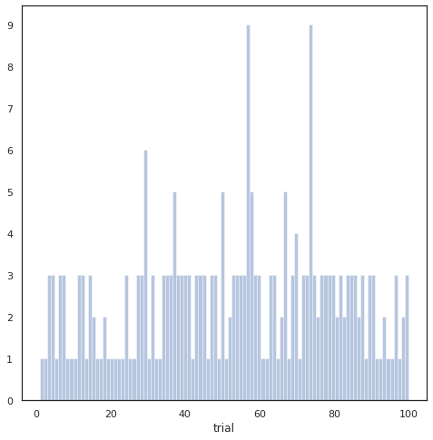

```python
ax = sns.distplot(lines_df["trial"], bins = 100,kde=False)
ax.yaxis.set_major_locator(ticker.MultipleLocator(1))
```

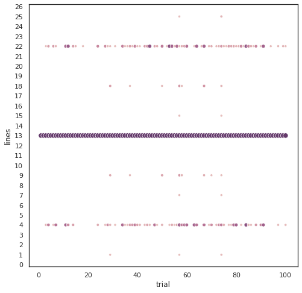

```python
cmap = sns.cubehelix_palette(dark=.3, light=.8, as_cmap=True)
ax = sns.scatterplot(x="trial",y="lines",hue="voi",size = "voi",data=lines_df,legend=False,palette=cmap,hue_norm=(0,50))
ax.yaxis.set_major_locator(ticker.MultipleLocator(1))
```

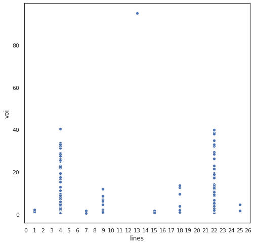

```python
ax = sns.scatterplot(x="lines",y="voi",data=lines_df)
ax.xaxis.set_major_locator(ticker.MultipleLocator(1))
```